# Customer Segmentation using Clustering

This mini-project is based on [this blog post](http://blog.yhat.com/posts/customer-segmentation-using-python.html) by yhat. Please feel free to refer to the post for additional information, and solutions.

```python
%matplotlib inline
import pandas as pd
import sklearn
import matplotlib.pyplot as plt
import seaborn as sns

# Setup Seaborn
sns.set_style("whitegrid")
sns.set_context("poster")
```

## Data

The dataset contains information on marketing newsletters/e-mail campaigns (e-mail offers sent to customers) and transaction level data from customers. The transactional data shows which offer customers responded to, and what the customer ended up buying. The data is presented as an Excel workbook containing two worksheets. Each worksheet contains a different dataset.

```python
df_offers = pd.read_excel("./WineKMC.xlsx", sheet_name=0)
df_offers.columns = ["offer_id", "campaign", "varietal", "min_qty", "discount", "origin", "past_peak"]
df_offers.head()
```

|  | offer_id | campaign | varietal | min_qty | discount | origin | past_peak |
| --- | --- | --- | --- | --- | --- | --- | --- |
| 0 | 1 | January | Malbec | 72 | 56 | France | False |
| 1 | 2 | January | Pinot Noir | 72 | 17 | France | False |
| 2 | 3 | February | Espumante | 144 | 32 | Oregon | True |
| 3 | 4 | February | Champagne | 72 | 48 | France | True |
| 4 | 5 | February | Cabernet Sauvignon | 144 | 44 | New Zealand | True |

```python
df_offers.info()
```

```
<class 'pandas.core.frame.DataFrame'>
RangeIndex: 32 entries, 0 to 31
Data columns (total 7 columns):
offer_id     32 non-null int64
campaign     32 non-null object
varietal     32 non-null object
min_qty      32 non-null int64
discount     32 non-null int64
origin       32 non-null object
past_peak    32 non-null bool
dtypes: bool(1), int64(3), object(3)
memory usage: 1.6+ KB
```

```python
df_offers.shape
```

```
(32, 7)
```

We see that the first dataset contains information about each offer such as the month it is in effect and several attributes about the wine that the offer refers to: the variety, minimum quantity, discount, country of origin and whether or not it is past peak. The second dataset in the second worksheet contains transactional data -- which offer each customer responded to.

```python
df_transactions = pd.read_excel("./WineKMC.xlsx", sheet_name=1)
df_transactions.columns = ["customer_name", "offer_id"]
df_transactions['n'] = 1
df_transactions.head()
```

|  | customer_name | offer_id | n |
| --- | --- | --- | --- |
| 0 | Smith | 2 | 1 |
| 1 | Smith | 24 | 1 |
| 2 | Johnson | 17 | 1 |
| 3 | Johnson | 24 | 1 |
| 4 | Johnson | 26 | 1 |

```python
df_transactions.info()
```

```
<class 'pandas.core.frame.DataFrame'>
RangeIndex: 324 entries, 0 to 323
Data columns (total 3 columns):
customer_name    324 non-null object
offer_id         324 non-null int64
n                324 non-null int64
dtypes: int64(2), object(1)
memory usage: 7.7+ KB
```

```python
df_transactions.shape
```

```
(324, 3)
```

## Data wrangling

We're trying to learn more about how our customers behave, so we can use their behavior (whether or not they purchased something based on an offer) as a way to group similar minded customers together. We can then study those groups to look for patterns and trends which can help us formulate future offers.

The first thing we need is a way to compare customers. To do this, we're going to create a matrix that contains each customer and a 0/1 indicator for whether or not they responded to a given offer.

### Checkup Exercise Set I

**Exercise:** Create a data frame where each row has the following columns (Use the pandas [`merge`](http://pandas.pydata.org/pandas-docs/stable/generated/pandas.DataFrame.merge.html) and [`pivot_table`](http://pandas.pydata.org/pandas-docs/stable/generated/pandas.pivot_table.html) functions for this purpose):

- customer_name
- One column for each offer, with a 1 if the customer responded to the offer

Make sure you also deal with any weird values such as `NaN`. Read the documentation to develop your solution.

```python
#your turn
# Merge the dataframes on offer_id
df = pd.merge(df_offers, df_transactions, on='offer_id')
df.head()
```

|  | offer_id | campaign | varietal | min_qty | discount | origin | past_peak | customer_name | n |
| --- | --- | --- | --- | --- | --- | --- | --- | --- | --- |
| 0 | 1 | January | Malbec | 72 | 56 | France | False | Thomas | 1 |
| 1 | 1 | January | Malbec | 72 | 56 | France | False | Jackson | 1 |
| 2 | 1 | January | Malbec | 72 | 56 | France | False | Mitchell | 1 |
| 3 | 1 | January | Malbec | 72 | 56 | France | False | Peterson | 1 |
| 4 | 1 | January | Malbec | 72 | 56 | France | False | Wood | 1 |

```python
df.info()
```

```
<class 'pandas.core.frame.DataFrame'>
Int64Index: 324 entries, 0 to 323
Data columns (total 9 columns):
offer_id         324 non-null int64
campaign         324 non-null object
varietal         324 non-null object
min_qty          324 non-null int64
discount         324 non-null int64
origin           324 non-null object
past_peak        324 non-null bool
customer_name    324 non-null object
n                324 non-null int64
dtypes: bool(1), int64(4), object(4)
memory usage: 23.1+ KB
```

```python
df.shape
```

```
(324, 9)
```

```python
# Now to get one column for each offer, we need to pivot the dataframe
matrix = df.pivot_table(index='customer_name', columns='offer_id', values='n') # values='n' is required here
matrix = matrix.reset_index()
matrix.fillna(0, inplace=True)
matrix
```

| offer_id | customer_name | 1 | 2 | 3 | 4 | 5 | 6 | 7 | 8 | 9 | ... | 23 | 24 | 25 | 26 | 27 | 28 | 29 | 30 | 31 | 32 |
| --- | --- | --- | --- | --- | --- | --- | --- | --- | --- | --- | --- | --- | --- | --- | --- | --- | --- | --- | --- | --- | --- |
| 0 | Adams | 0.0 | 0.0 | 0.0 | 0.0 | 0.0 | 0.0 | 0.0 | 0.0 | 0.0 | ... | 0.0 | 0.0 | 0.0 | 0.0 | 0.0 | 0.0 | 1.0 | 1.0 | 0.0 | 0.0 |
| 1 | Allen | 0.0 | 0.0 | 0.0 | 0.0 | 0.0 | 0.0 | 0.0 | 0.0 | 1.0 | ... | 0.0 | 0.0 | 0.0 | 0.0 | 1.0 | 0.0 | 0.0 | 0.0 | 0.0 | 0.0 |
| 2 | Anderson | 0.0 | 0.0 | 0.0 | 0.0 | 0.0 | 0.0 | 0.0 | 0.0 | 0.0 | ... | 0.0 | 1.0 | 0.0 | 1.0 | 0.0 | 0.0 | 0.0 | 0.0 | 0.0 | 0.0 |
| 3 | Bailey | 0.0 | 0.0 | 0.0 | 0.0 | 0.0 | 0.0 | 1.0 | 0.0 | 0.0 | ... | 0.0 | 0.0 | 0.0 | 0.0 | 0.0 | 0.0 | 0.0 | 1.0 | 0.0 | 0.0 |
| 4 | Baker | 0.0 | 0.0 | 0.0 | 0.0 | 0.0 | 0.0 | 1.0 | 0.0 | 0.0 | ... | 0.0 | 0.0 | 0.0 | 0.0 | 0.0 | 0.0 | 0.0 | 0.0 | 1.0 | 0.0 |
| 5 | Barnes | 0.0 | 0.0 | 0.0 | 0.0 | 0.0 | 0.0 | 0.0 | 0.0 | 0.0 | ... | 0.0 | 0.0 | 0.0 | 0.0 | 0.0 | 0.0 | 0.0 | 0.0 | 1.0 | 0.0 |
| 6 | Bell | 0.0 | 1.0 | 0.0 | 0.0 | 0.0 | 0.0 | 0.0 | 0.0 | 0.0 | ... | 0.0 | 1.0 | 0.0 | 1.0 | 0.0 | 0.0 | 0.0 | 0.0 | 0.0 | 0.0 |
| 7 | Bennett | 0.0 | 0.0 | 0.0 | 0.0 | 0.0 | 0.0 | 0.0 | 1.0 | 0.0 | ... | 0.0 | 0.0 | 0.0 | 0.0 | 0.0 | 0.0 | 1.0 | 0.0 | 0.0 | 0.0 |
| 8 | Brooks | 0.0 | 0.0 | 1.0 | 0.0 | 0.0 | 0.0 | 0.0 | 1.0 | 0.0 | ... | 0.0 | 0.0 | 0.0 | 0.0 | 0.0 | 0.0 | 0.0 | 0.0 | 0.0 | 0.0 |
| 9 | Brown | 0.0 | 0.0 | 0.0 | 0.0 | 0.0 | 0.0 | 1.0 | 0.0 | 0.0 | ... | 0.0 | 0.0 | 0.0 | 0.0 | 0.0 | 0.0 | 1.0 | 1.0 | 0.0 | 0.0 |
| 10 | Butler | 1.0 | 0.0 | 0.0 | 1.0 | 0.0 | 0.0 | 0.0 | 0.0 | 0.0 | ... | 0.0 | 0.0 | 0.0 | 0.0 | 0.0 | 1.0 | 0.0 | 1.0 | 0.0 | 0.0 |
| 11 | Campbell | 0.0 | 1.0 | 0.0 | 0.0 | 0.0 | 0.0 | 0.0 | 0.0 | 0.0 | ... | 0.0 | 1.0 | 0.0 | 1.0 | 0.0 | 0.0 | 0.0 | 0.0 | 0.0 | 0.0 |
| 12 | Carter | 0.0 | 0.0 | 0.0 | 0.0 | 0.0 | 0.0 | 1.0 | 0.0 | 0.0 | ... | 0.0 | 0.0 | 0.0 | 0.0 | 0.0 | 0.0 | 1.0 | 1.0 | 0.0 | 0.0 |
| 13 | Clark | 0.0 | 0.0 | 0.0 | 1.0 | 0.0 | 0.0 | 0.0 | 0.0 | 0.0 | ... | 0.0 | 0.0 | 0.0 | 0.0 | 0.0 | 1.0 | 0.0 | 0.0 | 1.0 | 0.0 |
| 14 | Collins | 0.0 | 0.0 | 0.0 | 0.0 | 0.0 | 0.0 | 0.0 | 0.0 | 0.0 | ... | 0.0 | 0.0 | 0.0 | 0.0 | 0.0 | 0.0 | 0.0 | 1.0 | 0.0 | 0.0 |
| 15 | Cook | 0.0 | 0.0 | 0.0 | 0.0 | 0.0 | 0.0 | 0.0 | 0.0 | 0.0 | ... | 0.0 | 1.0 | 0.0 | 1.0 | 0.0 | 0.0 | 0.0 | 0.0 | 0.0 | 0.0 |
| 16 | Cooper | 0.0 | 0.0 | 0.0 | 1.0 | 0.0 | 0.0 | 0.0 | 0.0 | 0.0 | ... | 0.0 | 0.0 | 0.0 | 0.0 | 0.0 | 0.0 | 0.0 | 0.0 | 0.0 | 1.0 |
| 17 | Cox | 0.0 | 1.0 | 0.0 | 0.0 | 0.0 | 0.0 | 0.0 | 0.0 | 0.0 | ... | 0.0 | 1.0 | 0.0 | 1.0 | 0.0 | 0.0 | 0.0 | 0.0 | 0.0 | 0.0 |
| 18 | Cruz | 0.0 | 0.0 | 0.0 | 0.0 | 0.0 | 0.0 | 0.0 | 0.0 | 0.0 | ... | 0.0 | 0.0 | 0.0 | 0.0 | 0.0 | 0.0 | 1.0 | 1.0 | 0.0 | 0.0 |
| 19 | Davis | 0.0 | 0.0 | 0.0 | 0.0 | 0.0 | 0.0 | 0.0 | 0.0 | 0.0 | ... | 0.0 | 0.0 | 1.0 | 0.0 | 0.0 | 0.0 | 0.0 | 0.0 | 0.0 | 0.0 |
| 20 | Diaz | 0.0 | 0.0 | 0.0 | 0.0 | 0.0 | 0.0 | 1.0 | 1.0 | 0.0 | ... | 0.0 | 0.0 | 0.0 | 0.0 | 0.0 | 0.0 | 1.0 | 1.0 | 0.0 | 0.0 |
| 21 | Edwards | 0.0 | 0.0 | 0.0 | 0.0 | 0.0 | 0.0 | 0.0 | 1.0 | 0.0 | ... | 0.0 | 0.0 | 0.0 | 0.0 | 1.0 | 0.0 | 0.0 | 0.0 | 0.0 | 0.0 |
| 22 | Evans | 0.0 | 0.0 | 0.0 | 0.0 | 0.0 | 0.0 | 0.0 | 0.0 | 0.0 | ... | 0.0 | 0.0 | 0.0 | 0.0 | 1.0 | 0.0 | 0.0 | 0.0 | 0.0 | 0.0 |
| 23 | Fisher | 1.0 | 1.0 | 0.0 | 0.0 | 0.0 | 0.0 | 0.0 | 0.0 | 0.0 | ... | 0.0 | 0.0 | 0.0 | 0.0 | 0.0 | 1.0 | 0.0 | 1.0 | 1.0 | 0.0 |
| 24 | Flores | 0.0 | 0.0 | 0.0 | 0.0 | 0.0 | 0.0 | 0.0 | 0.0 | 0.0 | ... | 0.0 | 1.0 | 0.0 | 0.0 | 0.0 | 0.0 | 0.0 | 0.0 | 0.0 | 0.0 |
| 25 | Foster | 1.0 | 0.0 | 0.0 | 0.0 | 0.0 | 0.0 | 0.0 | 0.0 | 1.0 | ... | 1.0 | 0.0 | 0.0 | 0.0 | 0.0 | 0.0 | 0.0 | 0.0 | 0.0 | 0.0 |
| 26 | Garcia | 0.0 | 0.0 | 0.0 | 0.0 | 0.0 | 0.0 | 0.0 | 0.0 | 0.0 | ... | 0.0 | 0.0 | 0.0 | 0.0 | 0.0 | 0.0 | 0.0 | 0.0 | 0.0 | 0.0 |
| 27 | Gomez | 0.0 | 0.0 | 0.0 | 0.0 | 0.0 | 0.0 | 0.0 | 0.0 | 0.0 | ... | 0.0 | 0.0 | 1.0 | 0.0 | 0.0 | 0.0 | 0.0 | 0.0 | 0.0 | 1.0 |
| 28 | Gonzalez | 0.0 | 0.0 | 0.0 | 0.0 | 0.0 | 0.0 | 0.0 | 0.0 | 1.0 | ... | 0.0 | 0.0 | 0.0 | 0.0 | 0.0 | 0.0 | 0.0 | 0.0 | 1.0 | 0.0 |
| 29 | Gray | 0.0 | 0.0 | 0.0 | 0.0 | 0.0 | 0.0 | 0.0 | 0.0 | 0.0 | ... | 0.0 | 0.0 | 0.0 | 1.0 | 0.0 | 0.0 | 0.0 | 0.0 | 0.0 | 0.0 |
| ... | ... | ... | ... | ... | ... | ... | ... | ... | ... | ... | ... | ... | ... | ... | ... | ... | ... | ... | ... | ... | ... |
| 70 | Reed | 0.0 | 0.0 | 0.0 | 0.0 | 1.0 | 0.0 | 0.0 | 0.0 | 0.0 | ... | 0.0 | 0.0 | 0.0 | 0.0 | 0.0 | 0.0 | 0.0 | 0.0 | 0.0 | 0.0 |
| 71 | Reyes | 0.0 | 0.0 | 0.0 | 0.0 | 0.0 | 0.0 | 0.0 | 0.0 | 1.0 | ... | 1.0 | 0.0 | 0.0 | 0.0 | 0.0 | 0.0 | 0.0 | 0.0 | 0.0 | 0.0 |
| 72 | Richardson | 0.0 | 0.0 | 1.0 | 0.0 | 0.0 | 1.0 | 0.0 | 0.0 | 0.0 | ... | 0.0 | 0.0 | 0.0 | 0.0 | 0.0 | 0.0 | 0.0 | 0.0 | 0.0 | 0.0 |
| 73 | Rivera | 0.0 | 0.0 | 0.0 | 0.0 | 0.0 | 0.0 | 1.0 | 0.0 | 0.0 | ... | 0.0 | 0.0 | 0.0 | 0.0 | 0.0 | 0.0 | 0.0 | 0.0 | 0.0 | 0.0 |
| 74 | Roberts | 0.0 | 0.0 | 0.0 | 0.0 | 0.0 | 0.0 | 0.0 | 0.0 | 0.0 | ... | 0.0 | 0.0 | 0.0 | 0.0 | 0.0 | 0.0 | 0.0 | 0.0 | 1.0 | 0.0 |
| 75 | Robinson | 0.0 | 0.0 | 0.0 | 0.0 | 0.0 | 0.0 | 1.0 | 0.0 | 0.0 | ... | 0.0 | 0.0 | 0.0 | 0.0 | 0.0 | 0.0 | 1.0 | 0.0 | 0.0 | 0.0 |
| 76 | Rodriguez | 0.0 | 1.0 | 0.0 | 0.0 | 0.0 | 0.0 | 0.0 | 0.0 | 0.0 | ... | 0.0 | 0.0 | 0.0 | 1.0 | 0.0 | 0.0 | 0.0 | 0.0 | 0.0 | 0.0 |
| 77 | Rogers | 0.0 | 0.0 | 1.0 | 0.0 | 0.0 | 0.0 | 1.0 | 1.0 | 0.0 | ... | 0.0 | 0.0 | 0.0 | 0.0 | 0.0 | 0.0 | 0.0 | 0.0 | 0.0 | 0.0 |
| 78 | Ross | 0.0 | 0.0 | 0.0 | 0.0 | 0.0 | 0.0 | 0.0 | 0.0 | 0.0 | ... | 0.0 | 0.0 | 0.0 | 0.0 | 0.0 | 0.0 | 0.0 | 0.0 | 0.0 | 0.0 |
| 79 | Russell | 0.0 | 0.0 | 0.0 | 0.0 | 0.0 | 0.0 | 0.0 | 0.0 | 0.0 | ... | 0.0 | 0.0 | 0.0 | 1.0 | 0.0 | 0.0 | 0.0 | 0.0 | 0.0 | 0.0 |
| 80 | Sanchez | 0.0 | 0.0 | 0.0 | 1.0 | 1.0 | 0.0 | 0.0 | 0.0 | 0.0 | ... | 0.0 | 0.0 | 0.0 | 1.0 | 0.0 | 0.0 | 0.0 | 0.0 | 0.0 | 0.0 |
| 81 | Sanders | 1.0 | 0.0 | 0.0 | 1.0 | 1.0 | 1.0 | 0.0 | 0.0 | 1.0 | ... | 0.0 | 0.0 | 1.0 | 1.0 | 0.0 | 0.0 | 0.0 | 0.0 | 0.0 | 0.0 |
| 82 | Scott | 0.0 | 0.0 | 0.0 | 0.0 | 0.0 | 1.0 | 0.0 | 0.0 | 0.0 | ... | 1.0 | 0.0 | 0.0 | 0.0 | 0.0 | 0.0 | 0.0 | 0.0 | 0.0 | 0.0 |
| 83 | Smith | 0.0 | 1.0 | 0.0 | 0.0 | 0.0 | 0.0 | 0.0 | 0.0 | 0.0 | ... | 0.0 | 1.0 | 0.0 | 0.0 | 0.0 | 0.0 | 0.0 | 0.0 | 0.0 | 0.0 |
| 84 | Stewart | 0.0 | 0.0 | 0.0 | 0.0 | 0.0 | 0.0 | 0.0 | 1.0 | 0.0 | ... | 0.0 | 0.0 | 0.0 | 0.0 | 0.0 | 0.0 | 1.0 | 1.0 | 0.0 | 0.0 |
| 85 | Sullivan | 0.0 | 0.0 | 0.0 | 0.0 | 0.0 | 0.0 | 0.0 | 1.0 | 0.0 | ... | 0.0 | 0.0 | 0.0 | 0.0 | 0.0 | 0.0 | 0.0 | 0.0 | 0.0 | 0.0 |
| 86 | Taylor | 0.0 | 0.0 | 0.0 | 0.0 | 0.0 | 0.0 | 1.0 | 0.0 | 0.0 | ... | 0.0 | 0.0 | 0.0 | 0.0 | 0.0 | 0.0 | 1.0 | 1.0 | 0.0 | 0.0 |
| 87 | Thomas | 1.0 | 0.0 | 0.0 | 1.0 | 0.0 | 0.0 | 0.0 | 0.0 | 1.0 | ... | 0.0 | 0.0 | 0.0 | 1.0 | 0.0 | 0.0 | 0.0 | 0.0 | 0.0 | 0.0 |
| 88 | Thompson | 0.0 | 0.0 | 0.0 | 0.0 | 0.0 | 0.0 | 0.0 | 0.0 | 1.0 | ... | 0.0 | 0.0 | 1.0 | 0.0 | 0.0 | 0.0 | 0.0 | 1.0 | 0.0 | 0.0 |
| 89 | Torres | 0.0 | 0.0 | 0.0 | 0.0 | 0.0 | 0.0 | 0.0 | 1.0 | 0.0 | ... | 0.0 | 0.0 | 0.0 | 0.0 | 0.0 | 0.0 | 0.0 | 0.0 | 0.0 | 0.0 |
| 90 | Turner | 0.0 | 0.0 | 0.0 | 1.0 | 0.0 | 1.0 | 0.0 | 0.0 | 0.0 | ... | 0.0 | 0.0 | 0.0 | 0.0 | 1.0 | 0.0 | 0.0 | 0.0 | 1.0 | 0.0 |
| 91 | Walker | 0.0 | 0.0 | 0.0 | 0.0 | 0.0 | 0.0 | 0.0 | 0.0 | 0.0 | ... | 0.0 | 0.0 | 0.0 | 0.0 | 0.0 | 0.0 | 1.0 | 0.0 | 0.0 | 0.0 |
| 92 | Ward | 0.0 | 0.0 | 0.0 | 1.0 | 0.0 | 0.0 | 0.0 | 0.0 | 0.0 | ... | 0.0 | 0.0 | 0.0 | 0.0 | 0.0 | 0.0 | 0.0 | 0.0 | 0.0 | 0.0 |
| 93 | Watson | 0.0 | 0.0 | 0.0 | 0.0 | 0.0 | 0.0 | 1.0 | 0.0 | 0.0 | ... | 0.0 | 0.0 | 0.0 | 0.0 | 0.0 | 0.0 | 1.0 | 0.0 | 0.0 | 0.0 |
| 94 | White | 0.0 | 0.0 | 0.0 | 0.0 | 0.0 | 0.0 | 0.0 | 0.0 | 0.0 | ... | 0.0 | 0.0 | 1.0 | 0.0 | 0.0 | 0.0 | 0.0 | 1.0 | 0.0 | 0.0 |
| 95 | Williams | 0.0 | 0.0 | 0.0 | 0.0 | 0.0 | 0.0 | 0.0 | 0.0 | 0.0 | ... | 0.0 | 0.0 | 0.0 | 0.0 | 0.0 | 0.0 | 0.0 | 0.0 | 1.0 | 0.0 |
| 96 | Wilson | 0.0 | 0.0 | 0.0 | 0.0 | 0.0 | 0.0 | 0.0 | 1.0 | 0.0 | ... | 0.0 | 0.0 | 0.0 | 0.0 | 0.0 | 0.0 | 0.0 | 1.0 | 0.0 | 0.0 |
| 97 | Wood | 1.0 | 0.0 | 0.0 | 0.0 | 0.0 | 0.0 | 0.0 | 0.0 | 0.0 | ... | 0.0 | 0.0 | 0.0 | 0.0 | 0.0 | 0.0 | 0.0 | 0.0 | 1.0 | 0.0 |
| 98 | Wright | 0.0 | 0.0 | 0.0 | 1.0 | 0.0 | 1.0 | 0.0 | 0.0 | 0.0 | ... | 0.0 | 0.0 | 0.0 | 0.0 | 1.0 | 0.0 | 0.0 | 0.0 | 0.0 | 0.0 |
| 99 | Young | 0.0 | 0.0 | 0.0 | 0.0 | 0.0 | 1.0 | 0.0 | 0.0 | 1.0 | ... | 0.0 | 0.0 | 0.0 | 0.0 | 0.0 | 0.0 | 0.0 | 0.0 | 1.0 | 1.0 |

100 rows × 33 columns

## K-Means Clustering

### Choosing K: The Elbow Sum-of-Squares Method

The first method looks at the sum-of-squares error in each cluster against $K$. We compute the distance from each data point to the center of the cluster (centroid) to which the data point was assigned.

$$SS = \sum_k \sum_{x_i \in C_k} \sum_{x_j \in C_k} \left( x_i - x_j \right)^2 = \sum_k \sum_{x_i \in C_k} \left( x_i - \mu_k \right)^2$$

where $x_i$ is a point, $C_k$ represents cluster $k$ and $\mu_k$ is the centroid for cluster $k$. We can plot SS vs. $K$ and choose the *elbow point* in the plot as the best value for $K$. The elbow point is the point at which the plot starts descending much more slowly.

### Checkup Exercise Set II

**Exercise:**

- What values of $SS$ do you believe represent better clusterings? Why?
- Create a numpy matrix `x_cols` with only the columns representing the offers (i.e. the 0/1 colums)
- Write code that applies the [`KMeans`](http://scikit-learn.org/stable/modules/generated/sklearn.cluster.KMeans.html) clustering method from scikit-learn to this matrix.
- Construct a plot showing $SS$ for each $K$ and pick $K$ using this plot. For simplicity, test $2 \le K \le 10$.
- Make a bar chart showing the number of points in each cluster for k-means under the best $K$.
- What challenges did you experience using the Elbow method to pick $K$?

**Answer SetIIa:** Smaller SS values represent better clustering, because they suggest that the distances between a cluster's centroid and datapoints is smaller.

```python
# your turn
# Create a nympy matrix with only the columns representing the offer
x_cols = matrix.iloc[:,1:33].values
type(x_cols)
```

```
numpy.ndarray
```

```python
x_cols
```

```
array([[0., 0., 0., ..., 1., 0., 0.],
       [0., 0., 0., ..., 0., 0., 0.],
       [0., 0., 0., ..., 0., 0., 0.],
       ...,
       [1., 0., 0., ..., 0., 1., 0.],
       [0., 0., 0., ..., 0., 0., 0.],
       [0., 0., 0., ..., 0., 1., 1.]])
```

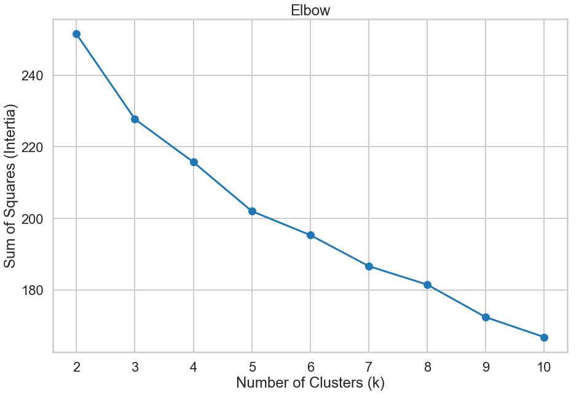

```python
# Write a code that applies the KMeans clustering method to this matrix
from sklearn.cluster import KMeans
sumofsquares = []
K = range(2,11)
for i in K:
    model = KMeans(n_clusters = i)
    model.fit_predict(x_cols)
    sumofsquares.append(model.inertia_)

# Construct a plot showing SS for each K.
plt.figure(figsize=(15,10))
plt.plot(K, sumofsquares, '-o')
plt.xlabel('Number of Clusters (k)')
plt.ylabel('Sum of Squares (Intertia)')
plt.title('Elbow')
plt.xticks(K)
plt.show()
```

```python
# dataframe for the number of clusters with corresponding Sum of Squares (inertia)
ss_df = pd.DataFrame({"Number of Clusters":K, "Sum of Squares":sumofsquares})
ss_df
```

|  | Number of Clusters | Sum of Squares |
| --- | --- | --- |
| 0 | 2 | 251.527778 |
| 1 | 3 | 227.736111 |
| 2 | 4 | 215.726174 |
| 3 | 5 | 202.009033 |
| 4 | 6 | 195.326407 |
| 5 | 7 | 186.643828 |
| 6 | 8 | 181.488971 |
| 7 | 9 | 172.390405 |
| 8 | 10 | 166.816291 |

```python
ss_df.shape
```

```
(9, 2)
```

```python
# Make a bar chart showing the number of points in each cluster for k-means under the best 𝐾
# I think the best K is 6
# Now let's do clustering with K as 6
model_cluster6 = KMeans(n_clusters = 6, random_state=42)
matrix['cluster_k6'] = model_cluster6.fit_predict(matrix.iloc[:,1:])
matrix.cluster_k6.value_counts()
```

```
1    36
4    24
2    16
5     9
0     8
3     7
Name: cluster_k6, dtype: int64
```

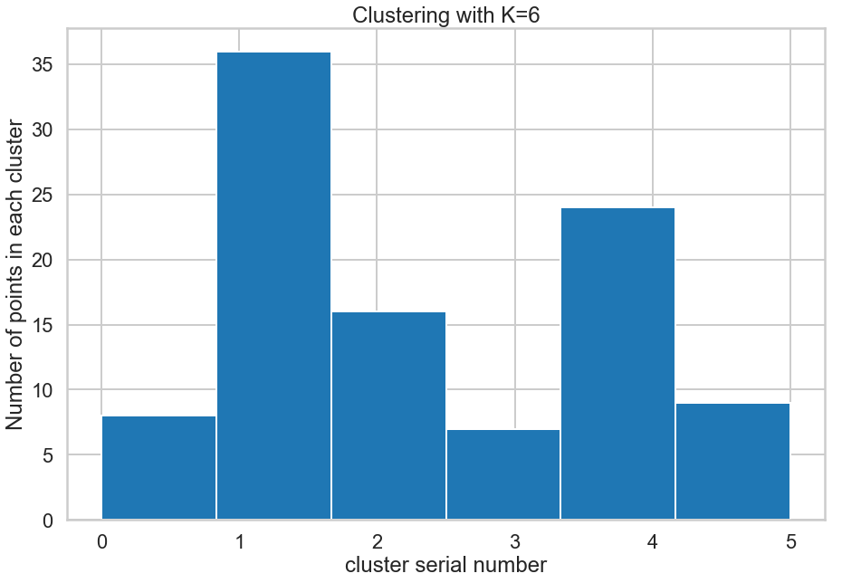

```python
plt.figure(figsize=(15,10))
plt.hist(matrix.cluster_k6, bins=6)
plt.xlabel("cluster serial number")
plt.ylabel("Number of points in each cluster")
plt.title('Clustering with K=6')
```

**Answer SetIIf:** *The challenge that I experienced using the elbow method is that there is not a distinct 'elbow' that would help me choose ideal K.*

### Choosing K: The Silhouette Method

There exists another method that measures how well each datapoint $x_i$ "fits" its assigned cluster *and also* how poorly it fits into other clusters. This is a different way of looking at the same objective. Denote $a_{x_i}$ as the *average* distance from $x_i$ to all other points within its own cluster $k$. The lower the value, the better. On the other hand $b_{x_i}$ is the minimum average distance from $x_i$ to points in a different cluster, minimized over clusters. That is, compute separately for each cluster the average distance from $x_i$ to the points within that cluster, and then take the minimum. The silhouette $s(x_i)$ is defined as

$$s(x_i) = \frac{b_{x_i} - a_{x_i}}{\max{\left( a_{x_i}, b_{x_i}\right)}}$$

The silhouette score is computed on *every datapoint in every cluster*. The silhouette score ranges from -1 (a poor clustering) to +1 (a very dense clustering) with 0 denoting the situation where clusters overlap. Some criteria for the silhouette coefficient is provided in the table below.

[output not shown]

Fortunately, scikit-learn provides a function to compute this for us (phew!) called [`sklearn.metrics.silhouette_score`](http://scikit-learn.org/stable/modules/generated/sklearn.metrics.silhouette_score.html). Take a look at [this article](http://scikit-learn.org/stable/auto_examples/cluster/plot_kmeans_silhouette_analysis.html) on picking $K$ in scikit-learn, as it will help you in the next exercise set.

### Checkup Exercise Set III

**Exercise:** Using the documentation for the `silhouette_score` function above, construct a series of silhouette plots like the ones in the article linked above.

**Exercise:** Compute the average silhouette score for each $K$ and plot it. What $K$ does the plot suggest we should choose? Does it differ from what we found using the Elbow method?

```
For 2 clusters , the average silhouette score is 0.09174871508750351
For 3 clusters , the average silhouette score is 0.11542407037894219
For 4 clusters , the average silhouette score is 0.09670258360693122
For 5 clusters , the average silhouette score is 0.14531568820332333
For 6 clusters , the average silhouette score is 0.13313126627114877
For 7 clusters , the average silhouette score is 0.13073950771832585
For 8 clusters , the average silhouette score is 0.12397572901124844
For 9 clusters , the average silhouette score is 0.1202465110942483
For 10 clusters , the average silhouette score is 0.12695143123424532
```

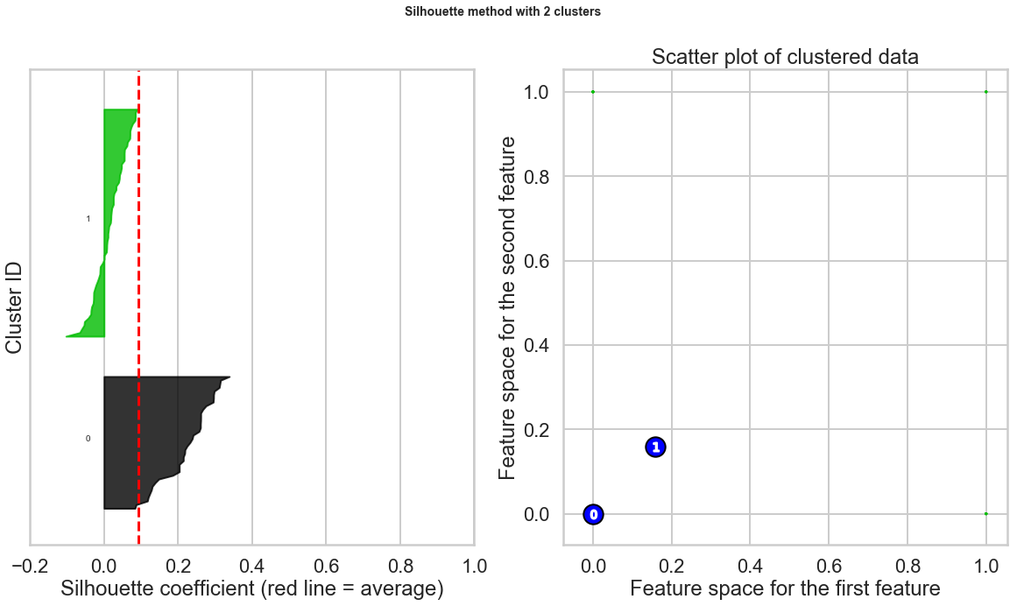

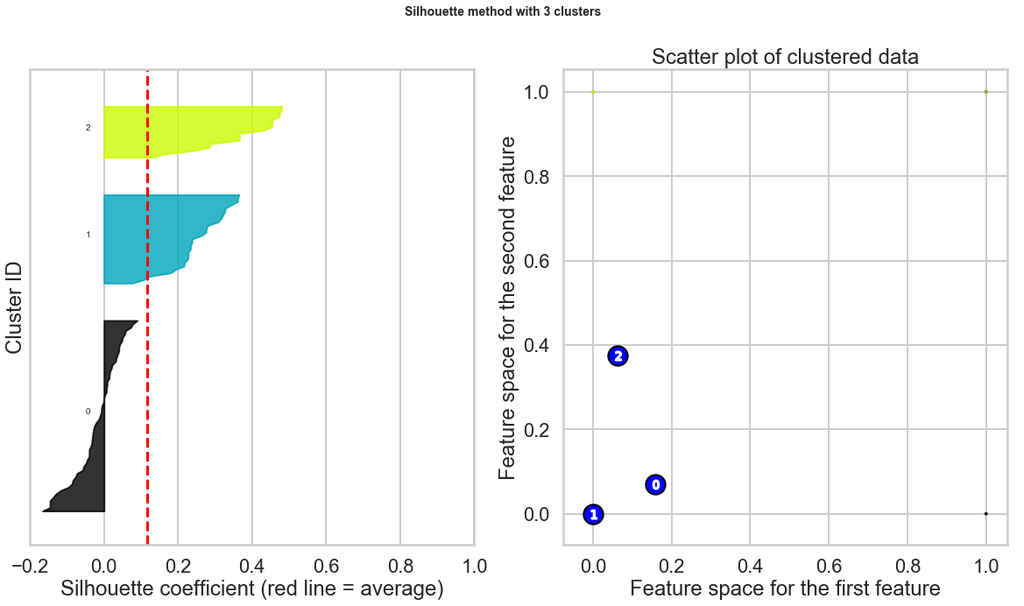

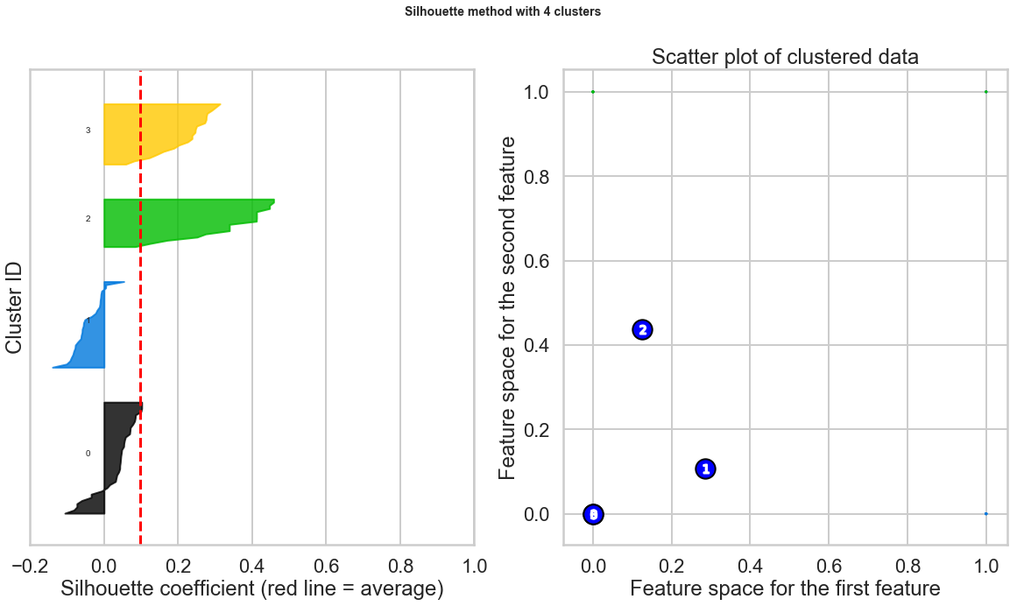

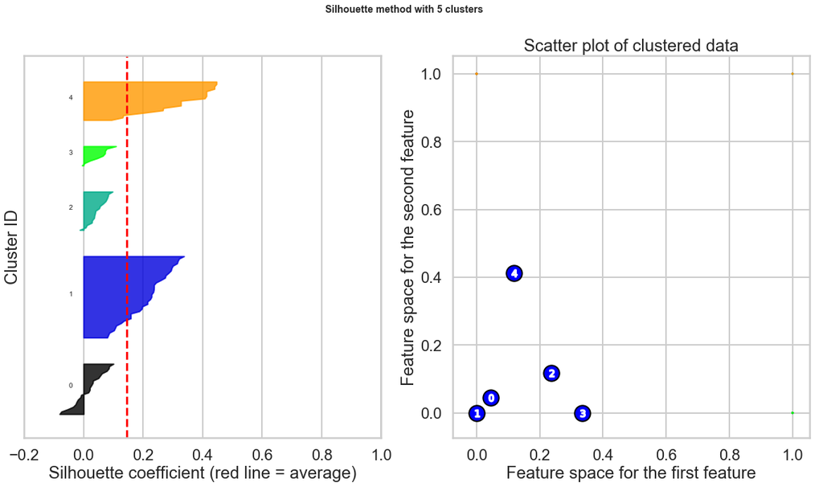

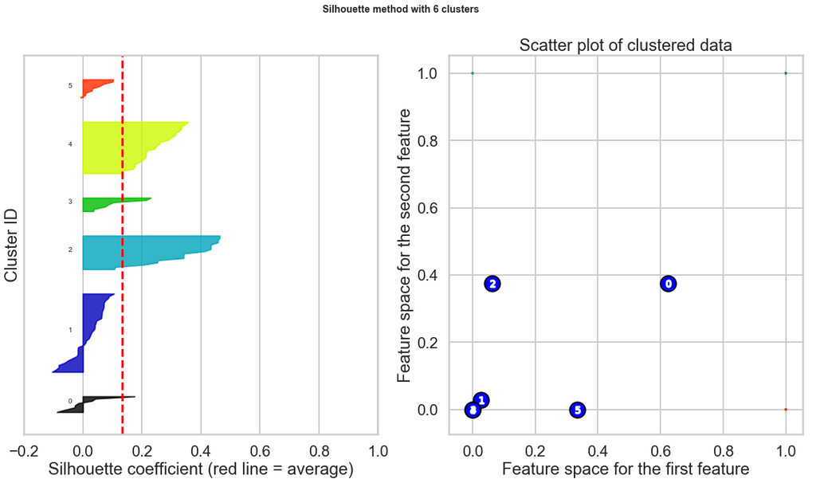

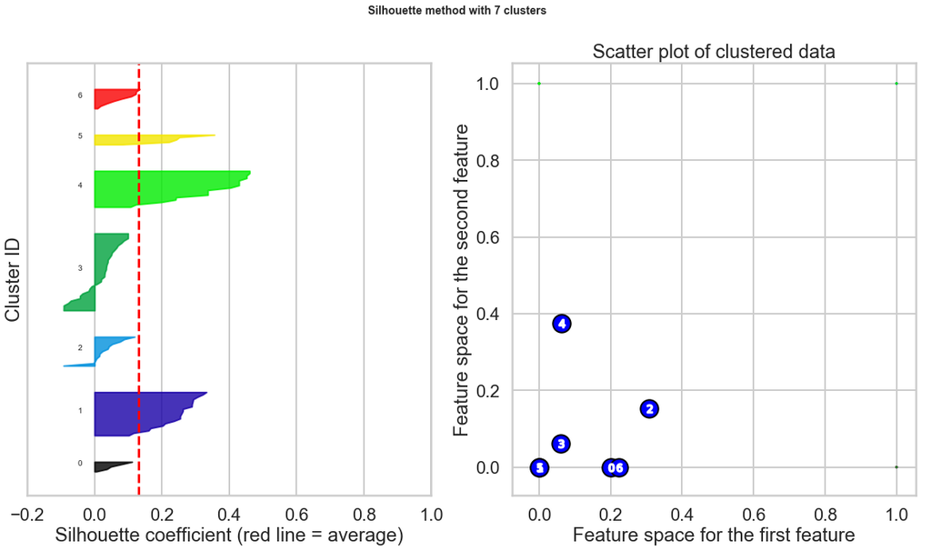

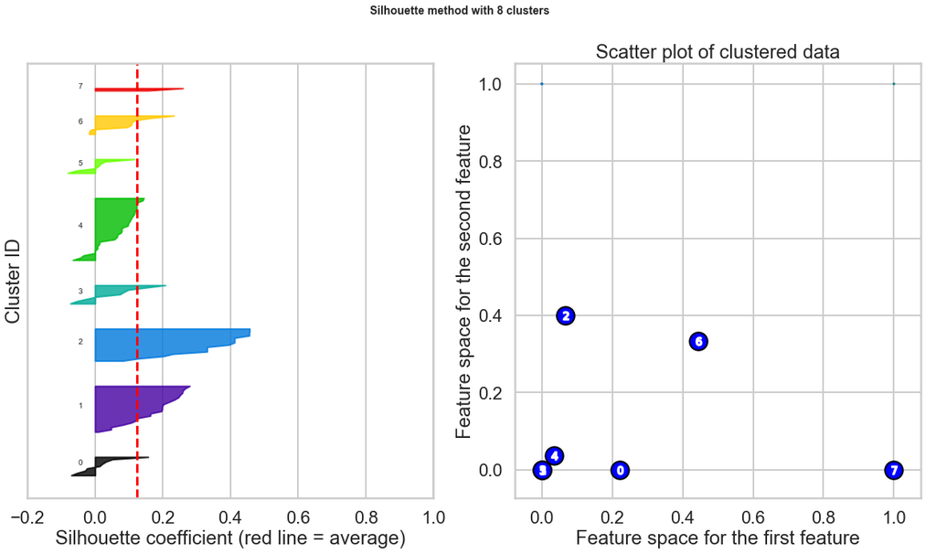

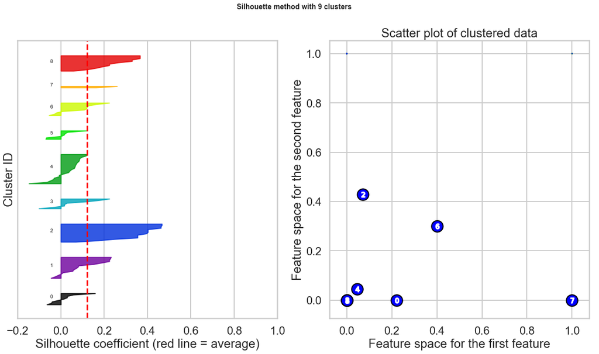

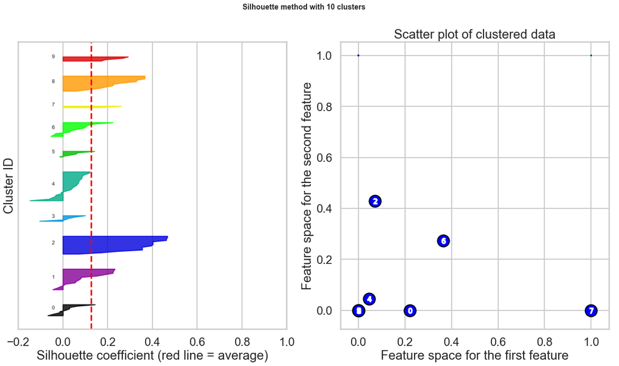

```python
# Your turn.
from sklearn.metrics import silhouette_samples, silhouette_score
import matplotlib.cm as cm
import numpy as np

K = range(2,11)

for i in K:
    # create a subplot with 1 row and 2 columns
    fig, (ax1, ax2) = plt.subplots(1,2)
    fig.set_size_inches(20, 10)

    # although the silhouette coefficient ranges from -1 to 1, here we will limit to -0.2 and 0.6
    ax1.set_xlim([-0.2, 0.5])
    # Now put white spaces around the margins
    ax1.set_ylim([0, len(x_cols) + (i+1)*10])

    clust = KMeans(n_clusters=i, random_state=42)
    cluster_id = clust.fit_predict(x_cols)

    # silhouette average
    sil_avg = silhouette_score(x_cols, cluster_id)
    print("For", i, "clusters , the average silhouette score is", sil_avg)

    # Calculate the silhouette scores for each sample
    sil_score_sample = silhouette_samples(x_cols, cluster_id)

    y_lower = 10
    for j in range(i):
        # Aggregate silhouette scores for samples in cluster j, and sort them
        sil_score_jth_cluster = sil_score_sample[cluster_id == j]
        sil_score_jth_cluster.sort()

        cluster_j_size = sil_score_jth_cluster.shape[0]

        y_upper = y_lower + cluster_j_size

        color = cm.nipy_spectral(float(j)/i)
        ax1.fill_betweenx(np.arange(y_lower, y_upper), 0, sil_score_jth_cluster,
                         facecolor=color, edgecolor=color, alpha=0.8)

        # Labeling the silhouette plots with cluster numbers
        ax1.text(-0.05, y_lower + 0.5 * cluster_j_size, str(j))

        # Calculate the new y_lower for next plot
        y_lower = y_upper + 10

    # Now we are out of "for j in range(i) loop"
    ax1.set_xlabel("Silhouette coefficient (red line = average)")
    ax1.set_ylabel("Cluster ID")

    # Draw a vertical red line for average silhouette scores
    ax1.axvline(x=sil_avg, color='red', linestyle="--")

    ax1.set_yticks([])  # Clear the yaxis labels / ticks
    ax1.set_xticks([-0.2, 0, 0.2, 0.4, 0.6, 0.8, 1])


    # 2nd Plot showing the actual clusters formed
    colors = cm.nipy_spectral(cluster_id.astype(float)/i)

    ax2.scatter(x_cols[:,0], x_cols[:,1], marker='.', s=40, lw=0, alpha=0.8, c=colors, edgecolor='k')

    # Label the clusters
    cluster_centers = clust.cluster_centers_

    # Draw blue circles at cluster centers
    ax2.scatter(cluster_centers[:, 0], cluster_centers[:,1], marker='o',s=500,c='blue', alpha=1, edgecolor='k')

    # Now label the circles with white numbers
    for a, b in enumerate(cluster_centers):
        ax2.scatter(b[0], b[1], marker='$%d$' % a, alpha=1, s=100, edgecolor='w')

    ax2.set_title("Scatter plot of clustered data")
    ax2.set_xlabel("Feature space for the first feature")
    ax2.set_ylabel("Feature space for the second feature")

    plt.suptitle(("Silhouette method with %d clusters" % i), fontsize=14, fontweight='bold')

plt.show()
```

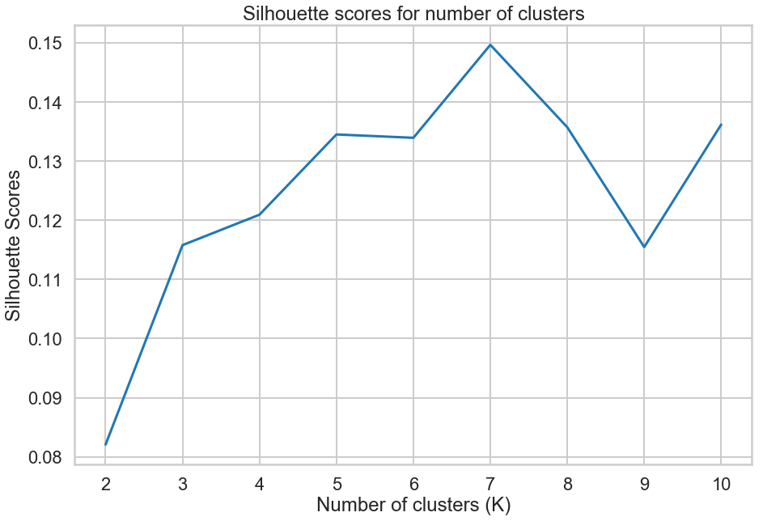

```python
my_list = []
K = range(2,11)
for i in K:
    kmeans = KMeans(n_clusters = i)
    pred = kmeans.fit_predict(x_cols)
    sil_score = silhouette_score(x_cols, pred)
    my_list.append(sil_score)

plt.figure(figsize=(15,10))
plt.plot(K, my_list)
plt.title("Silhouette scores for number of clusters")
plt.xlabel('Number of clusters (K)')
plt.ylabel('Silhouette Scores')
plt.show()
```

### Choosing $K$: The Gap Statistic

There is one last method worth covering for picking $K$, the so-called Gap statistic. The computation for the gap statistic builds on the sum-of-squares established in the Elbow method discussion, and compares it to the sum-of-squares of a "null distribution," that is, a random set of points with no clustering. The estimate for the optimal number of clusters $K$ is the value for which $\log{SS}$ falls the farthest below that of the reference distribution:

$$G_k = E_n^*\{\log SS_k\} - \log SS_k$$

In other words a good clustering yields a much larger difference between the reference distribution and the clustered data. The reference distribution is a Monte Carlo (randomization) procedure that constructs $B$ random distributions of points within the bounding box (limits) of the original data and then applies K-means to this synthetic distribution of data points.. $E_n^*\{\log SS_k\}$ is just the average $SS_k$ over all $B$ replicates. We then compute the standard deviation $\sigma_{SS}$ of the values of $SS_k$ computed from the $B$ replicates of the reference distribution and compute

$$s_k = \sqrt{1+1/B}\sigma_{SS}$$

Finally, we choose $K=k$ such that $G_k \geq G_{k+1} - s_{k+1}$.

### Aside: Choosing $K$ when we Have Labels

Unsupervised learning expects that we do not have the labels. In some situations, we may wish to cluster data that is labeled. Computing the optimal number of clusters is much easier if we have access to labels. There are several methods available. We will not go into the math or details since it is rare to have access to the labels, but we provide the names and references of these measures.

- Adjusted Rand Index
- Mutual Information
- V-Measure
- Fowlkes–Mallows index

See [this article](http://scikit-learn.org/stable/modules/clustering.html) for more information about these metrics.

## Visualizing Clusters using PCA

How do we visualize clusters? If we only had two features, we could likely plot the data as is. But we have 100 data points each containing 32 features (dimensions). Principal Component Analysis (PCA) will help us reduce the dimensionality of our data from 32 to something lower. For a visualization on the coordinate plane, we will use 2 dimensions. In this exercise, we're going to use it to transform our multi-dimensional dataset into a 2 dimensional dataset.

This is only one use of PCA for dimension reduction. We can also use PCA when we want to perform regression but we have a set of highly correlated variables. PCA untangles these correlations into a smaller number of features/predictors all of which are orthogonal (not correlated). PCA is also used to reduce a large set of variables into a much smaller one.

### Checkup Exercise Set IV

**Exercise:** Use PCA to plot your clusters:

- Use scikit-learn's [`PCA`](http://scikit-learn.org/stable/modules/generated/sklearn.decomposition.PCA.html) function to reduce the dimensionality of your clustering data to 2 components
- Create a data frame with the following fields:
  - customer name
  - cluster id the customer belongs to
  - the two PCA components (label them `x` and `y`)
- Plot a scatterplot of the `x` vs `y` columns
- Color-code points differently based on cluster ID
- How do the clusters look?
- Based on what you see, what seems to be the best value for $K$? Moreover, which method of choosing $K$ seems to have produced the optimal result visually?

**Exercise:** Now look at both the original raw data about the offers and transactions and look at the fitted clusters. Tell a story about the clusters in context of the original data. For example, do the clusters correspond to wine variants or something else interesting?

```python
# Let's recap how the matrix looks like
matrix.head()
```

| offer_id | customer_name | 1 | 2 | 3 | 4 | 5 | 6 | 7 | 8 | 9 | ... | 24 | 25 | 26 | 27 | 28 | 29 | 30 | 31 | 32 | cluster_k6 |
| --- | --- | --- | --- | --- | --- | --- | --- | --- | --- | --- | --- | --- | --- | --- | --- | --- | --- | --- | --- | --- | --- |
| 0 | Adams | 0.0 | 0.0 | 0.0 | 0.0 | 0.0 | 0.0 | 0.0 | 0.0 | 0.0 | ... | 0.0 | 0.0 | 0.0 | 0.0 | 0.0 | 1.0 | 1.0 | 0.0 | 0.0 | 4 |
| 1 | Allen | 0.0 | 0.0 | 0.0 | 0.0 | 0.0 | 0.0 | 0.0 | 0.0 | 1.0 | ... | 0.0 | 0.0 | 0.0 | 1.0 | 0.0 | 0.0 | 0.0 | 0.0 | 0.0 | 1 |
| 2 | Anderson | 0.0 | 0.0 | 0.0 | 0.0 | 0.0 | 0.0 | 0.0 | 0.0 | 0.0 | ... | 1.0 | 0.0 | 1.0 | 0.0 | 0.0 | 0.0 | 0.0 | 0.0 | 0.0 | 2 |
| 3 | Bailey | 0.0 | 0.0 | 0.0 | 0.0 | 0.0 | 0.0 | 1.0 | 0.0 | 0.0 | ... | 0.0 | 0.0 | 0.0 | 0.0 | 0.0 | 0.0 | 1.0 | 0.0 | 0.0 | 4 |
| 4 | Baker | 0.0 | 0.0 | 0.0 | 0.0 | 0.0 | 0.0 | 1.0 | 0.0 | 0.0 | ... | 0.0 | 0.0 | 0.0 | 0.0 | 0.0 | 0.0 | 0.0 | 1.0 | 0.0 | 1 |

5 rows × 34 columns

```python
#your turn
from sklearn.decomposition import PCA

pca = PCA(n_components=2)
matrix['pca_x'] = pca.fit_transform(matrix.iloc[:,1:33])[:,0]
matrix['pca_y'] = pca.fit_transform(matrix.iloc[:,1:33])[:,1]

new_matrix = matrix[[ 'customer_name','cluster_k6','pca_x', 'pca_y']]
new_matrix.head()
```

| offer_id | customer_name | cluster_k6 | pca_x | pca_y |
| --- | --- | --- | --- | --- |
| 0 | Adams | 4 | 1.007580 | 0.108215 |
| 1 | Allen | 1 | -0.287539 | 0.044715 |
| 2 | Anderson | 2 | -0.392032 | 1.038391 |
| 3 | Bailey | 4 | 0.699477 | -0.022542 |
| 4 | Baker | 1 | 0.088183 | -0.471695 |

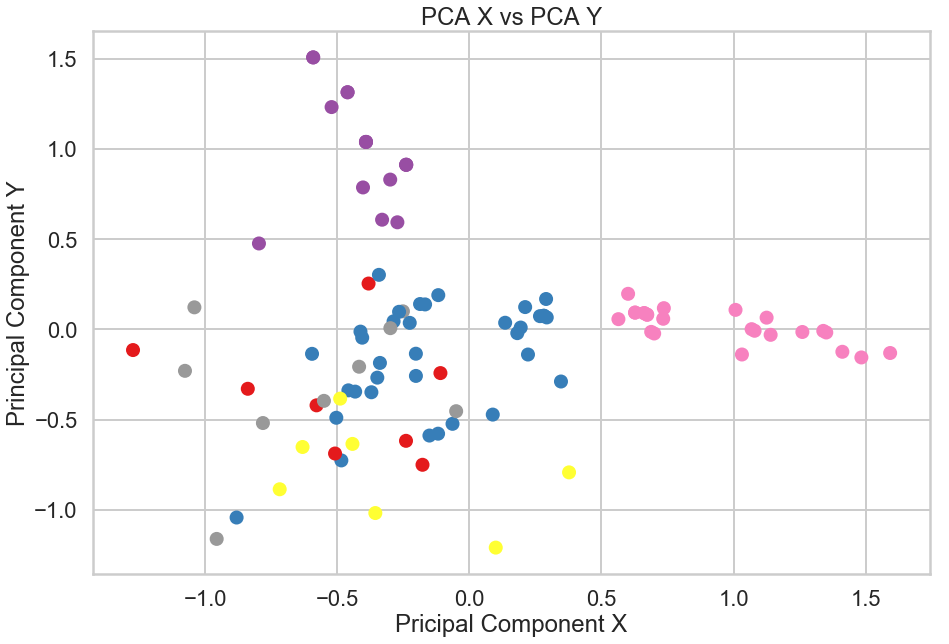

```python
plt.figure(figsize=(15,10))
plt.scatter(new_matrix['pca_x'].values,new_matrix['pca_y'].values,
            c=new_matrix['cluster_k6'].values, cmap='Set1')
plt.xlabel('Pricipal Component X', fontsize=24)
plt.ylabel('Principal Component Y', fontsize=24)
plt.title('PCA X vs PCA Y')
plt.show()
```

What we've done is we've taken those columns of 0/1 indicator variables, and we've transformed them into a 2-D dataset. We took one column and arbitrarily called it `x` and then called the other `y`. Now we can throw each point into a scatterplot. We color coded each point based on it's cluster so it's easier to see them.

### Exercise Set V

As we saw earlier, PCA has a lot of other uses. Since we wanted to visualize our data in 2 dimensions, restricted the number of dimensions to 2 in PCA. But what is the true optimal number of dimensions?

**Exercise:** Using a new PCA object shown in the next cell, plot the `explained_variance_` field and look for the elbow point, the point where the curve's rate of descent seems to slow sharply. This value is one possible value for the optimal number of dimensions. What is it?

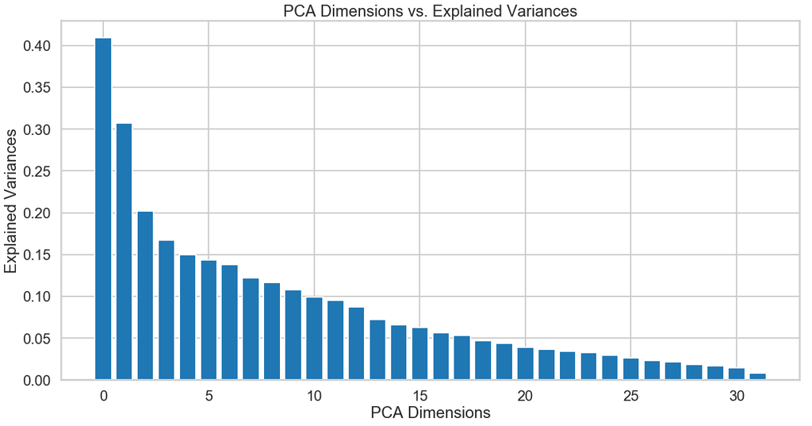

```python
#your turn
# Initialize a new PCA model with a default number of components.
import sklearn.decomposition
pca = sklearn.decomposition.PCA()
pca.fit(x_cols)

# Do the rest on your own :)
features = range(pca.n_components_)
explained_variance = pca.explained_variance_
plt.figure(figsize=(20,10))
plt.bar(features, explained_variance)
plt.title("PCA Dimensions vs. Explained Variances")
plt.xlabel("PCA Dimensions")
plt.ylabel("Explained Variances")
plt.show()
```

**Answer: The most notable inflection is between 3 or 4 (I've hard time picking) because after that the decrease seems to be gradual.**

## Other Clustering Algorithms

k-means is only one of a ton of clustering algorithms. Below is a brief description of several clustering algorithms, and the table provides references to the other clustering algorithms in scikit-learn.

- **Affinity Propagation** does not require the number of clusters $K$ to be known in advance! AP uses a "message passing" paradigm to cluster points based on their similarity.
- **Spectral Clustering** uses the eigenvalues of a similarity matrix to reduce the dimensionality of the data before clustering in a lower dimensional space. This is tangentially similar to what we did to visualize k-means clusters using PCA. The number of clusters must be known a priori.
- **Ward's Method** applies to hierarchical clustering. Hierarchical clustering algorithms take a set of data and successively divide the observations into more and more clusters at each layer of the hierarchy. Ward's method is used to determine when two clusters in the hierarchy should be combined into one. It is basically an extension of hierarchical clustering. Hierarchical clustering is *divisive*, that is, all observations are part of the same cluster at first, and at each successive iteration, the clusters are made smaller and smaller. With hierarchical clustering, a hierarchy is constructed, and there is not really the concept of "number of clusters." The number of clusters simply determines how low or how high in the hierarchy we reference and can be determined empirically or by looking at the [dendogram](https://docs.scipy.org/doc/scipy-0.18.1/reference/generated/scipy.cluster.hierarchy.dendrogram.html).
- **Agglomerative Clustering** is similar to hierarchical clustering but but is not divisive, it is *agglomerative*. That is, every observation is placed into its own cluster and at each iteration or level or the hierarchy, observations are merged into fewer and fewer clusters until convergence. Similar to hierarchical clustering, the constructed hierarchy contains all possible numbers of clusters and it is up to the analyst to pick the number by reviewing statistics or the dendogram.
- **DBSCAN** is based on point density rather than distance. It groups together points with many nearby neighbors. DBSCAN is one of the most cited algorithms in the literature. It does not require knowing the number of clusters a priori, but does require specifying the neighborhood size.

### Clustering Algorithms in Scikit-learn

Method name

Parameters

Scalability

Use Case

Geometry (metric used)

K-Means

number of clusters

Very largen_samples, medium n_clusters with MiniBatch code

General-purpose, even cluster size, flat geometry, not too many clusters

Distances between points

Affinity propagation

damping, sample preference

Not scalable with n_samples

Many clusters, uneven cluster size, non-flat geometry

Graph distance (e.g. nearest-neighbor graph)

Mean-shift

bandwidth

Not scalable with n_samples

Many clusters, uneven cluster size, non-flat geometry

Distances between points

Spectral clustering

number of clusters

Medium n_samples, small n_clusters

Few clusters, even cluster size, non-flat geometry

Graph distance (e.g. nearest-neighbor graph)

Ward hierarchical clustering

number of clusters

Large n_samples and n_clusters

Many clusters, possibly connectivity constraints

Distances between points

Agglomerative clustering

number of clusters, linkage type, distance

Large n_samples and n_clusters

Many clusters, possibly connectivity constraints, non Euclidean distances

Any pairwise distance

DBSCAN

neighborhood size

Very large n_samples, medium n_clusters

Non-flat geometry, uneven cluster sizes

Distances between nearest points

Gaussian mixtures

many

Not scalable

Flat geometry, good for density estimation

Mahalanobis distances to centers

Birch

branching factor, threshold, optional global clusterer.

Large n_clusters and n_samples

Large dataset, outlier removal, data reduction.

Euclidean distance between points

### Exercise Set VI

**Exercise:** Try clustering using the following algorithms.

1. Affinity propagation
2. Spectral clustering
3. Agglomerative clustering
4. DBSCAN

How do their results compare? Which performs the best? Tell a story why you think it performs the best.

```python
# Your turn
```

### Affinity porpagation

```python
silhouette_scores = {}

from sklearn.cluster import AffinityPropagation

ap = AffinityPropagation()

clust_ap = ap.fit(matrix.iloc[:,1:33])
cluster_center_indices = ap.cluster_centers_indices_
number_of_clusters = len(cluster_center_indices)
ap_labels = clust_ap.labels_
matrix['clust_ap'] = ap_labels
matrix.head()
```

| offer_id | customer_name | 1 | 2 | 3 | 4 | 5 | 6 | 7 | 8 | 9 | ... | 27 | 28 | 29 | 30 | 31 | 32 | cluster_k6 | pca_x | pca_y | clust_ap |
| --- | --- | --- | --- | --- | --- | --- | --- | --- | --- | --- | --- | --- | --- | --- | --- | --- | --- | --- | --- | --- | --- |
| 0 | Adams | 0.0 | 0.0 | 0.0 | 0.0 | 0.0 | 0.0 | 0.0 | 0.0 | 0.0 | ... | 0.0 | 0.0 | 1.0 | 1.0 | 0.0 | 0.0 | 4 | 1.007580 | 0.108215 | 0 |
| 1 | Allen | 0.0 | 0.0 | 0.0 | 0.0 | 0.0 | 0.0 | 0.0 | 0.0 | 1.0 | ... | 1.0 | 0.0 | 0.0 | 0.0 | 0.0 | 0.0 | 1 | -0.287539 | 0.044715 | 10 |
| 2 | Anderson | 0.0 | 0.0 | 0.0 | 0.0 | 0.0 | 0.0 | 0.0 | 0.0 | 0.0 | ... | 0.0 | 0.0 | 0.0 | 0.0 | 0.0 | 0.0 | 2 | -0.392032 | 1.038391 | 6 |
| 3 | Bailey | 0.0 | 0.0 | 0.0 | 0.0 | 0.0 | 0.0 | 1.0 | 0.0 | 0.0 | ... | 0.0 | 0.0 | 0.0 | 1.0 | 0.0 | 0.0 | 4 | 0.699477 | -0.022542 | 3 |
| 4 | Baker | 0.0 | 0.0 | 0.0 | 0.0 | 0.0 | 0.0 | 1.0 | 0.0 | 0.0 | ... | 0.0 | 0.0 | 0.0 | 0.0 | 1.0 | 0.0 | 1 | 0.088183 | -0.471695 | 3 |

5 rows × 37 columns

```python
ap_labels
```

```
array([ 0, 10,  6,  3,  3, 12,  6,  7,  4,  2,  9, 13,  2, 12,  4,  6,  3,
        6,  0,  1,  2,  7,  4,  9,  6, 10, 11,  4, 12, 13,  3,  7,  4,  8,
        0,  5,  4,  2,  4,  5,  6,  6,  7, 12,  0,  8,  2,  3, 10, 13,  1,
       12, 13,  6,  7,  7,  6,  3,  0,  7, 12,  7, 12,  0,  0, 13,  6, 11,
        9, 10, 11, 10,  8,  3, 12,  3, 13,  3,  3, 13, 11, 10, 11, 13,  2,
        5,  0, 10, 10,  7, 12,  0,  7,  3,  1, 12,  7, 12,  8, 12],
      dtype=int64)
```

```python
ap_labels_unique = set(ap_labels)
ap_labels_unique
```

```
{0, 1, 2, 3, 4, 5, 6, 7, 8, 9, 10, 11, 12, 13}
```

```python
matrix.clust_ap.value_counts()
```

```
12    12
7     11
3     11
6     10
0      9
13     8
10     8
4      7
2      6
11     5
8      4
9      3
5      3
1      3
Name: clust_ap, dtype: int64
```

```python
sil = silhouette_score(matrix.iloc[:,1:33], ap_labels, metric='sqeuclidean')
silhouette_scores['Affinity Propagation'] = sil
```

```python
print('Estimated number of clusters: %d' % number_of_clusters)
print("Silhouette Coefficient: %0.3f" % sil)
```

```
Estimated number of clusters: 14
Silhouette Coefficient: 0.180
```

### Spectral clustering

```python
from sklearn.cluster import SpectralClustering

sc = SpectralClustering(n_clusters=6, assign_labels="discretize", random_state=42)
clust_sc = sc.fit(matrix.iloc[:,1:33])
sc_labels = clust_sc.labels_
matrix['clust_sc'] = sc_labels
matrix.head()
```

| offer_id | customer_name | 1 | 2 | 3 | 4 | 5 | 6 | 7 | 8 | 9 | ... | 28 | 29 | 30 | 31 | 32 | cluster_k6 | pca_x | pca_y | clust_ap | clust_sc |
| --- | --- | --- | --- | --- | --- | --- | --- | --- | --- | --- | --- | --- | --- | --- | --- | --- | --- | --- | --- | --- | --- |
| 0 | Adams | 0.0 | 0.0 | 0.0 | 0.0 | 0.0 | 0.0 | 0.0 | 0.0 | 0.0 | ... | 0.0 | 1.0 | 1.0 | 0.0 | 0.0 | 4 | 1.007580 | 0.108215 | 0 | 2 |
| 1 | Allen | 0.0 | 0.0 | 0.0 | 0.0 | 0.0 | 0.0 | 0.0 | 0.0 | 1.0 | ... | 0.0 | 0.0 | 0.0 | 0.0 | 0.0 | 1 | -0.287539 | 0.044715 | 10 | 0 |
| 2 | Anderson | 0.0 | 0.0 | 0.0 | 0.0 | 0.0 | 0.0 | 0.0 | 0.0 | 0.0 | ... | 0.0 | 0.0 | 0.0 | 0.0 | 0.0 | 2 | -0.392032 | 1.038391 | 6 | 1 |
| 3 | Bailey | 0.0 | 0.0 | 0.0 | 0.0 | 0.0 | 0.0 | 1.0 | 0.0 | 0.0 | ... | 0.0 | 0.0 | 1.0 | 0.0 | 0.0 | 4 | 0.699477 | -0.022542 | 3 | 5 |
| 4 | Baker | 0.0 | 0.0 | 0.0 | 0.0 | 0.0 | 0.0 | 1.0 | 0.0 | 0.0 | ... | 0.0 | 0.0 | 0.0 | 1.0 | 0.0 | 1 | 0.088183 | -0.471695 | 3 | 0 |

5 rows × 38 columns

```python
sc_labels_unique = set(sc_labels)
sc_labels_unique
```

```
{0, 1, 2, 3, 4, 5}
```

```python
matrix.clust_sc.value_counts()
```

```
0    44
5    16
1    14
3    10
2     9
4     7
Name: clust_sc, dtype: int64
```

```python
sil = silhouette_score(matrix.iloc[:,1:33], sc_labels, metric='sqeuclidean')
silhouette_scores['Spectral Clustering'] = sil

print("Silhouette Coefficient: %0.3f" % sil)
```

```
Silhouette Coefficient: 0.132
```

### Agglomerative Clustering

```python
from sklearn.cluster import AgglomerativeClustering

aggc = AgglomerativeClustering(n_clusters=6)
clust_aggc = aggc.fit(matrix.iloc[:,1:33])
aggc_labels = clust_aggc.labels_
matrix['clust_aggc'] = aggc_labels
matrix.head()
```

| offer_id | customer_name | 1 | 2 | 3 | 4 | 5 | 6 | 7 | 8 | 9 | ... | 29 | 30 | 31 | 32 | cluster_k6 | pca_x | pca_y | clust_ap | clust_sc | clust_aggc |
| --- | --- | --- | --- | --- | --- | --- | --- | --- | --- | --- | --- | --- | --- | --- | --- | --- | --- | --- | --- | --- | --- |
| 0 | Adams | 0.0 | 0.0 | 0.0 | 0.0 | 0.0 | 0.0 | 0.0 | 0.0 | 0.0 | ... | 1.0 | 1.0 | 0.0 | 0.0 | 4 | 1.007580 | 0.108215 | 0 | 2 | 1 |
| 1 | Allen | 0.0 | 0.0 | 0.0 | 0.0 | 0.0 | 0.0 | 0.0 | 0.0 | 1.0 | ... | 0.0 | 0.0 | 0.0 | 0.0 | 1 | -0.287539 | 0.044715 | 10 | 0 | 0 |
| 2 | Anderson | 0.0 | 0.0 | 0.0 | 0.0 | 0.0 | 0.0 | 0.0 | 0.0 | 0.0 | ... | 0.0 | 0.0 | 0.0 | 0.0 | 2 | -0.392032 | 1.038391 | 6 | 1 | 2 |
| 3 | Bailey | 0.0 | 0.0 | 0.0 | 0.0 | 0.0 | 0.0 | 1.0 | 0.0 | 0.0 | ... | 0.0 | 1.0 | 0.0 | 0.0 | 4 | 0.699477 | -0.022542 | 3 | 5 | 1 |
| 4 | Baker | 0.0 | 0.0 | 0.0 | 0.0 | 0.0 | 0.0 | 1.0 | 0.0 | 0.0 | ... | 0.0 | 0.0 | 1.0 | 0.0 | 1 | 0.088183 | -0.471695 | 3 | 0 | 0 |

5 rows × 39 columns

```python
aggc_labels_unique = set(aggc_labels)
aggc_labels_unique
```

```
{0, 1, 2, 3, 4, 5}
```

```python
matrix.clust_aggc.value_counts()
```

```
1    34
0    30
2    17
3     8
4     7
5     4
Name: clust_aggc, dtype: int64
```

```python
sil = silhouette_score(matrix.iloc[:,1:33], aggc_labels, metric='sqeuclidean')
silhouette_scores['Agglomerative Clustering'] = sil
print("Silhouette Coefficient: %0.3f" % sil)
```

```
Silhouette Coefficient: 0.232
```

### DBSCAN

```python
from sklearn.cluster import DBSCAN
from sklearn.preprocessing import StandardScaler

#ss = StandardScaler()
#matrix_ss = ss.fit_transform(matrix[['pca_x', 'pca_y']])

db = DBSCAN(min_samples=3,eps=0.3)
#clust_db = db.fit_predict(matrix_ss)
clust_db = db.fit_predict(matrix.iloc[:,1:33])
#db_labels = clust_db.labels_
matrix['clust_DBSCAN'] = clust_db
matrix.head()
```

| offer_id | customer_name | 1 | 2 | 3 | 4 | 5 | 6 | 7 | 8 | 9 | ... | 30 | 31 | 32 | cluster_k6 | pca_x | pca_y | clust_ap | clust_sc | clust_aggc | clust_DBSCAN |
| --- | --- | --- | --- | --- | --- | --- | --- | --- | --- | --- | --- | --- | --- | --- | --- | --- | --- | --- | --- | --- | --- |
| 0 | Adams | 0.0 | 0.0 | 0.0 | 0.0 | 0.0 | 0.0 | 0.0 | 0.0 | 0.0 | ... | 1.0 | 0.0 | 0.0 | 4 | 1.007580 | 0.108215 | 0 | 2 | 1 | -1 |
| 1 | Allen | 0.0 | 0.0 | 0.0 | 0.0 | 0.0 | 0.0 | 0.0 | 0.0 | 1.0 | ... | 0.0 | 0.0 | 0.0 | 1 | -0.287539 | 0.044715 | 10 | 0 | 0 | -1 |
| 2 | Anderson | 0.0 | 0.0 | 0.0 | 0.0 | 0.0 | 0.0 | 0.0 | 0.0 | 0.0 | ... | 0.0 | 0.0 | 0.0 | 2 | -0.392032 | 1.038391 | 6 | 1 | 2 | 0 |
| 3 | Bailey | 0.0 | 0.0 | 0.0 | 0.0 | 0.0 | 0.0 | 1.0 | 0.0 | 0.0 | ... | 1.0 | 0.0 | 0.0 | 4 | 0.699477 | -0.022542 | 3 | 5 | 1 | -1 |
| 4 | Baker | 0.0 | 0.0 | 0.0 | 0.0 | 0.0 | 0.0 | 1.0 | 0.0 | 0.0 | ... | 0.0 | 1.0 | 0.0 | 1 | 0.088183 | -0.471695 | 3 | 0 | 0 | -1 |

5 rows × 40 columns

```python
db_labels = set(clust_db)
db_labels
```

```
{-1, 0, 1, 2}
```

```python
matrix.clust_DBSCAN.value_counts()
```

```
-1    91
 1     3
 2     3
 0     3
Name: clust_DBSCAN, dtype: int64
```

```python
sil = silhouette_score(matrix.iloc[:,1:33], clust_db, metric='sqeuclidean')
silhouette_scores['DBSCAN'] = sil
print("Silhouette Coefficient: %0.3f" % sil)
```

```
Silhouette Coefficient: -0.259
```

#### Plotting

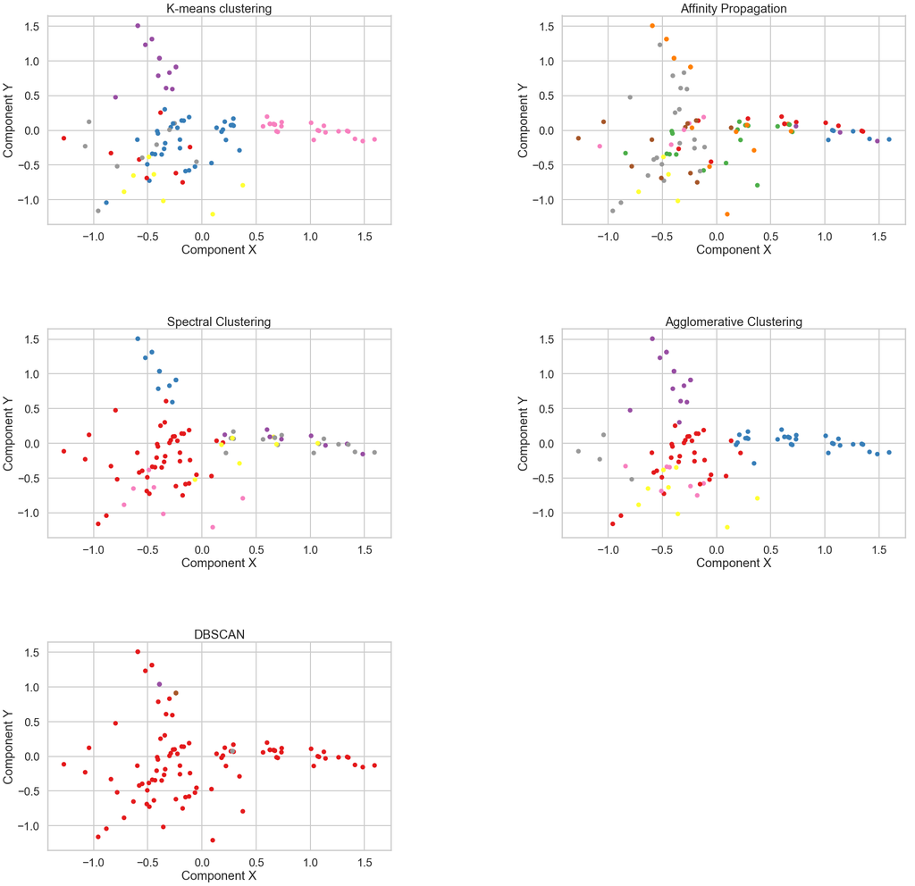

```python
fig = plt.figure(figsize=(30,30))
plt.subplots_adjust(wspace=0.5, hspace=0.5) # adjust spaces between subplots
ax1 = fig.add_subplot(321)
ax1.scatter(matrix['pca_x'], matrix['pca_y'], s=50, c=matrix['cluster_k6'], cmap='Set1')
ax1.set_title('K-means clustering')
ax1.set_xlabel('Component X')
ax1.set_ylabel('Component Y')


ax2 = fig.add_subplot(322)
ax2.scatter(matrix['pca_x'], matrix['pca_y'], s=50, c=matrix['clust_ap'], cmap='Set1')
ax2.set_title('Affinity Propagation')
ax2.set_xlabel('Component X')
ax2.set_ylabel('Component Y')

ax3 = fig.add_subplot(323)
ax3.scatter(matrix['pca_x'], matrix['pca_y'], s=50, c=matrix['clust_sc'], cmap='Set1')
ax3.set_title('Spectral Clustering')
ax3.set_xlabel('Component X')
ax3.set_ylabel('Component Y')

ax4 = fig.add_subplot(324)
ax4.scatter(matrix['pca_x'], matrix['pca_y'], s=50, c=matrix['clust_aggc'], cmap='Set1')
ax4.set_title('Agglomerative Clustering')
ax4.set_xlabel('Component X')
ax4.set_ylabel('Component Y')

ax5 = fig.add_subplot(325)
ax5.scatter(matrix['pca_x'], matrix['pca_y'], s=50, c=matrix['clust_DBSCAN'], cmap='Set1')
ax5.set_title('DBSCAN')
ax5.set_xlabel('Component X')
ax5.set_ylabel('Component Y')
```

#### Plotting in 3D

```python
# For plotting in 3D, we need to add third principal component
pca_3d = PCA(n_components=3)
matrix['pca_x'] = pca_3d.fit_transform(matrix.iloc[:,1:33])[:,0]
matrix['pca_y'] = pca_3d.fit_transform(matrix.iloc[:,1:33])[:,1]
matrix['pca_z'] = pca_3d.fit_transform(matrix.iloc[:,1:33])[:,2]
```

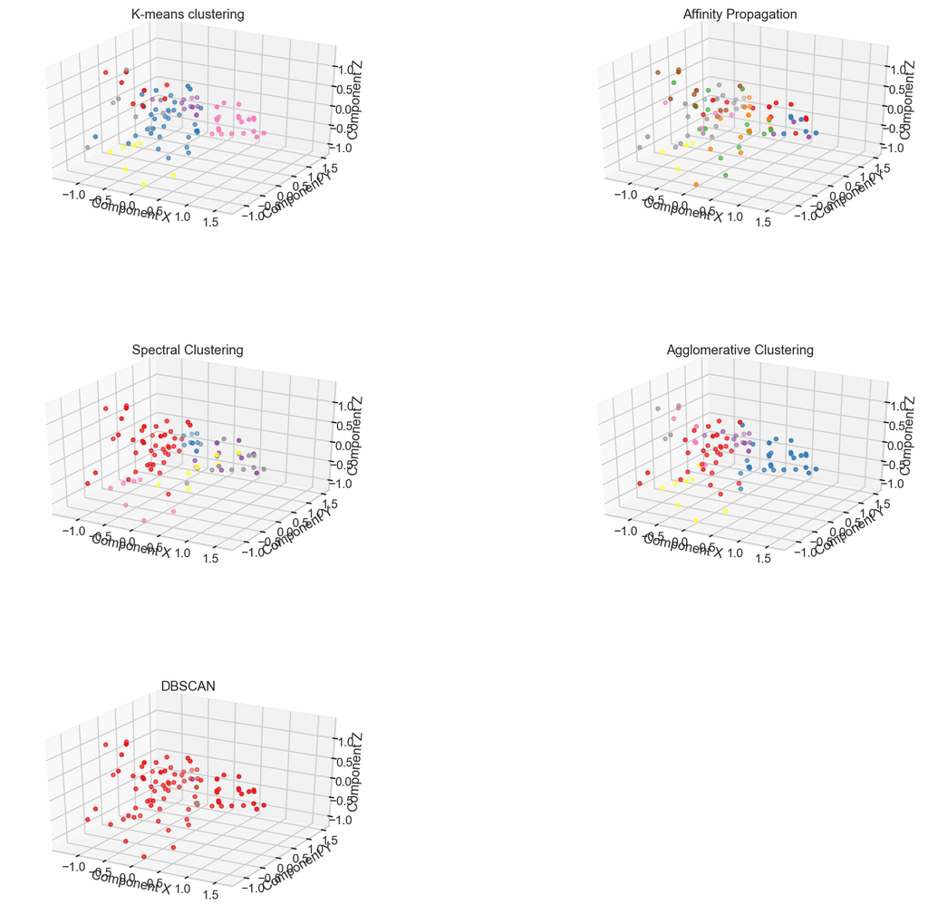

```python
# for 3D projection we need to import following
from mpl_toolkits.mplot3d import axes3d, Axes3D #<-- Note the capitalization!
fig = plt.figure(figsize=(30,30))
plt.subplots_adjust(wspace=0.5, hspace=0.5) # adjust spaces between subplots
ax1 = fig.add_subplot(321, projection='3d')
ax1.scatter(matrix['pca_x'], matrix['pca_y'], matrix['pca_z'], s=50, c=matrix['cluster_k6'], cmap='Set1')
ax1.set_title('K-means clustering')
ax1.set_xlabel('Component X')
ax1.set_ylabel('Component Y')
ax1.set_zlabel('Component Z')

ax2 = fig.add_subplot(322, projection='3d')
ax2.scatter(matrix['pca_x'], matrix['pca_y'], matrix['pca_z'], s=50, c=matrix['clust_ap'], cmap='Set1')
ax2.set_title('Affinity Propagation')
ax2.set_xlabel('Component X')
ax2.set_ylabel('Component Y')
ax2.set_zlabel('Component Z')

ax3 = fig.add_subplot(323, projection='3d')
ax3.scatter(matrix['pca_x'], matrix['pca_y'], matrix['pca_z'], s=50, c=matrix['clust_sc'], cmap='Set1')
ax3.set_title('Spectral Clustering')
ax3.set_xlabel('Component X')
ax3.set_ylabel('Component Y')
ax3.set_zlabel('Component Z')

ax4 = fig.add_subplot(324, projection='3d')
ax4.scatter(matrix['pca_x'], matrix['pca_y'], matrix['pca_z'], s=50, c=matrix['clust_aggc'], cmap='Set1')
ax4.set_title('Agglomerative Clustering')
ax4.set_xlabel('Component X')
ax4.set_ylabel('Component Y')
ax4.set_zlabel('Component Z')

ax5 = fig.add_subplot(325, projection='3d')
ax5.scatter(matrix['pca_x'], matrix['pca_y'], matrix['pca_z'], s=50, c=matrix['clust_DBSCAN'], cmap='Set1')
ax5.set_title('DBSCAN')
ax5.set_xlabel('Component X')
ax5.set_ylabel('Component Y')
ax5.set_zlabel('Component Z')
```

```python
index = [0]
sil_df = pd.DataFrame(silhouette_scores, index=index)
sil_df = sil_df.T
sil_df.columns = ['Silhouette Scores']
sil_df
```

|  | Silhouette Scores |
| --- | --- |
| Affinity Propagation | 0.179783 |
| Spectral Clustering | 0.131994 |
| Agglomerative Clustering | 0.231666 |
| DBSCAN | -0.258930 |

**Answer Set VI: Based on the silhouette scores of the four algorithms, Agglomerative Clustering is the best. If we look at the plots, Agglomerative clustering and K-means clustering appear to be the best. I believe Affinity Propagation and DBSCAN were the poor performers because the former gave 14 clusters and the latter gave 4 (that includes a negative 1). The two best performers seem to pick the optimal K.**